# Homework 2 cahpter3

Author

Guibril Ramde

## 3.7 Exercises

Do exercises 3.1, 3.2, 3.3, 3.4, 3.5, 3.7, 3.8 and 3.9 from the online Hyndman book. Please include your Rpubs link along with.pdf file of your run code

## 3.1

Consider the GDP information in `global_economy`. Plot the GDP per capita for each country over time. Which country has the highest GDP per capita? How has this changed over time?

```r
library(tidyverse)
library(dplyr)
library(ggplot2)
#install.packages("fpp3")
library(ggtime)
library(fpp3)
```

since we have a large datasets it is safe to find the highest GDP per capita for every year, then observe their changes over time by using plot.

```r
global_economy |>
  mutate(gdp_per_capita = GDP/Population ) |>
  filter(!is.na(gdp_per_capita)) |>
  as_tibble() |>
  group_by(Year) |>
  slice_max(
    order_by = gdp_per_capita,
    n = 1,
    with_ties = FALSE
  ) |>
  select(Year, Country, gdp_per_capita)
```

```
# A tibble: 58 × 3
# Groups:   Year [58]
    Year Country       gdp_per_capita
   <dbl> <fct>                  <dbl>
 1  1960 United States          3007.
 2  1961 United States          3067.
 3  1962 United States          3244.
 4  1963 United States          3375.
 5  1964 United States          3574.
 6  1965 Kuwait                 4429.
 7  1966 Kuwait                 4556.
 8  1967 United States          4336.
 9  1968 United States          4696.
10  1969 United States          5032.
# ℹ 48 more rows
```

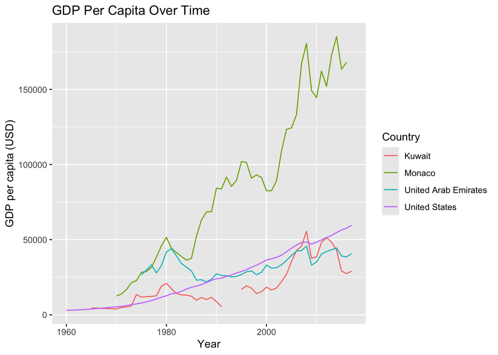

```r
global_economy |>
  mutate(gdp_per_capita = GDP / Population) |>
  filter(
    Country %in% c(
      "United States",
      "Kuwait",
      "Monaco",
      "United Arab Emirates"
    )
  ) |>
  ggplot(aes(
    x = Year,
    y = gdp_per_capita,
    color = Country
  )) +
  geom_line(na.rm = TRUE) +
  labs(
    title = "GDP Per Capita Over Time",
    x = "Year",
    y = "GDP per capita (USD)",
    color = "Country"
  )
```

**##Interpretation**

The country with the highest GDP per capita for most of the period is Monaco. Monaco shows a strong upward trend over time, although there are some periods of decline, especially around 1980’s, 2000 and 2010. Overall, Monaco’s GDP per capita increased significantly over time. The United Arab Emirates, the United States, and Kuwait also show an overall upward trend. The United States has a more stable trend, while Kuwait, Monaco, and the United Arab Emirates show more fluctuations and several periods of decline.

## **3.2 .For each of the following series, make a graph of the data. If transforming seems appropriate, do so and describe the effect.**

- United States GDP from `global_economy`.

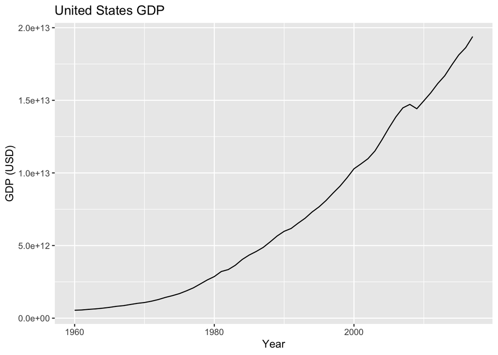

```r
global_economy |>
  filter(Country == "United States") |>
  autoplot(GDP) +
  labs(title = "United States GDP",
    x = "Year",
    y = "GDP (USD)")
```

## **Interpretation**

The original U.S. GDP series shows a strong upward trend, with the magnitude of the changes increasing as GDP increases. The log transformation compresses the larger values and makes the growth pattern more nearly linear, helping to stabilize the variation over time.

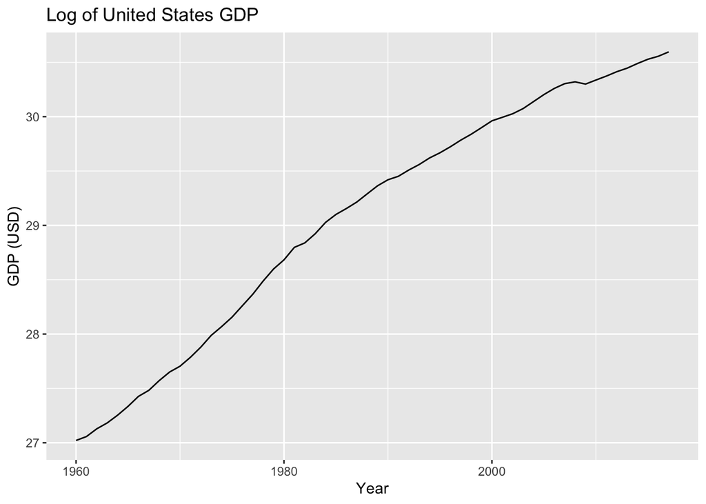

```r
global_economy |>
  filter(Country == "United States") |>
  autoplot(log(GDP)) +
  labs(title = "Log of United States GDP",
    x = "Year",
    y = "GDP (USD)")
```

- Slaughter of Victorian “Bulls, bullocks and steers” in `aus_livestock`.

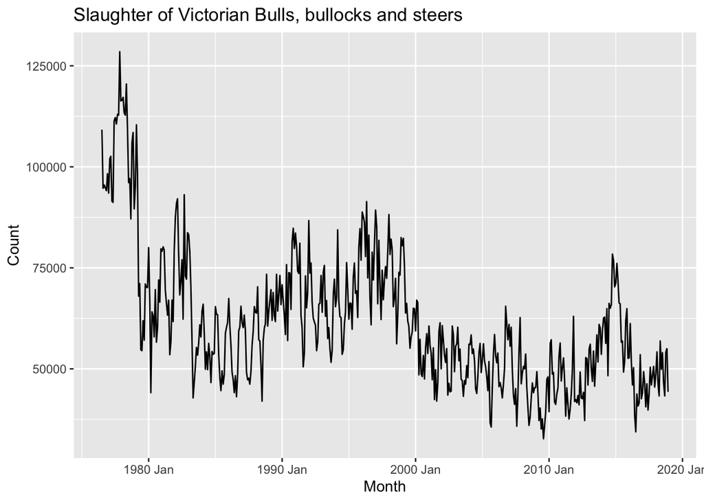

```r
aus_livestock |>
  filter(State == "Victoria",
         Animal == "Bulls, bullocks and steers") |>
  ggplot(aes(x = Month, y = Count)) +
  geom_line() +
  labs(title = "Slaughter of Victorian Bulls, bullocks and steers", x = "Month", y = "Count")
```

```r
victoria_bulls <- aus_livestock |>
  filter(
    State == "Victoria",
    Animal == "Bulls, bullocks and steers"
  )

dcmp <- victoria_bulls |>
  model(stl = STL(Count))

components(dcmp)
```

```
# A dable: 510 x 9 [1M]
# Key:     Animal, State, .model [1]
# :        Count = trend + season_year + remainder
   Animal              State .model    Month  Count  trend season_year remainder
   <fct>               <fct> <chr>     <mth>  <dbl>  <dbl>       <dbl>     <dbl>
 1 Bulls, bullocks an… Vict… stl    1976 Jul 109200 9.51e4      -1381.    15518.
 2 Bulls, bullocks an… Vict… stl    1976 Aug  94700 9.58e4      -6576.     5518.
 3 Bulls, bullocks an… Vict… stl    1976 Sep  95500 9.65e4      -5098.     4144.
 4 Bulls, bullocks an… Vict… stl    1976 Oct  94800 9.71e4       1347.    -3695.
 5 Bulls, bullocks an… Vict… stl    1976 Nov  94100 9.81e4       3241.    -7203.
 6 Bulls, bullocks an… Vict… stl    1976 Dec  98300 9.90e4       3765.    -4441.
 7 Bulls, bullocks an… Vict… stl    1977 Jan  93500 9.99e4       6980.   -13369.
 8 Bulls, bullocks an… Vict… stl    1977 Feb 102000 1.01e5       9526.    -8402.
 9 Bulls, bullocks an… Vict… stl    1977 Mar 102600 1.02e5       3375.    -2637.
10 Bulls, bullocks an… Vict… stl    1977 Apr  91500 1.03e5      -4146.    -7203.
# ℹ 500 more rows
# ℹ 1 more variable: season_adjust <dbl>
```

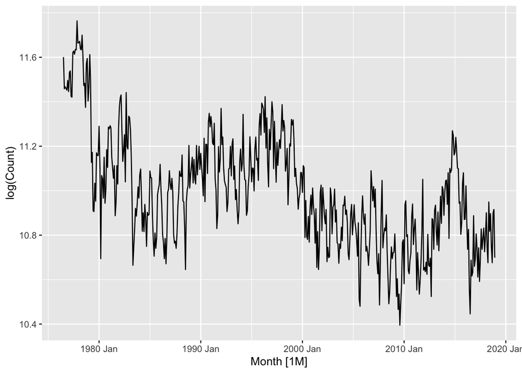

```r
victoria_bulls |>
  autoplot(log(Count))
```

**##Interpretation**

we could use a log transformation for aus_livestock observation over time, and by using a log transformation we see that the original series ranges differ from the transformed series ranges, but the overall pattern and variability remain similar to the original series.

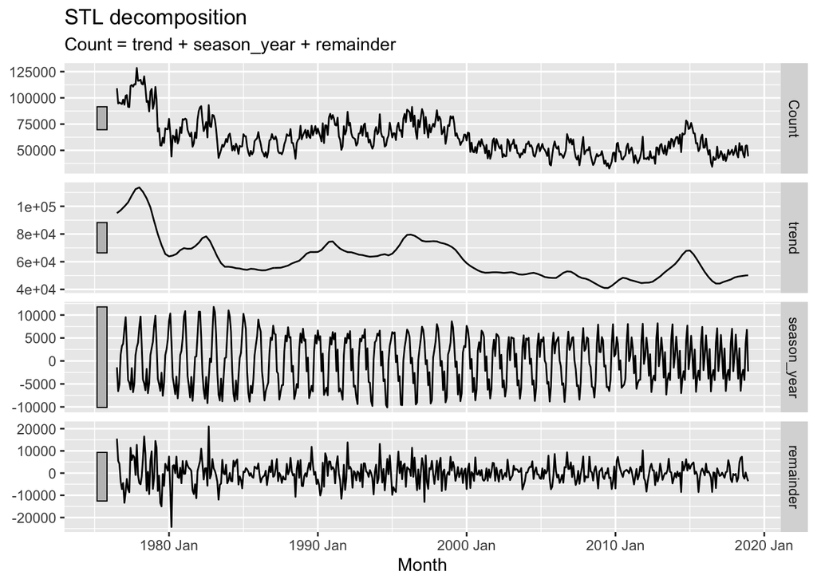

```r
components(dcmp) |> autoplot()
```

- Victorian Electricity Demand from `vic_elec`.

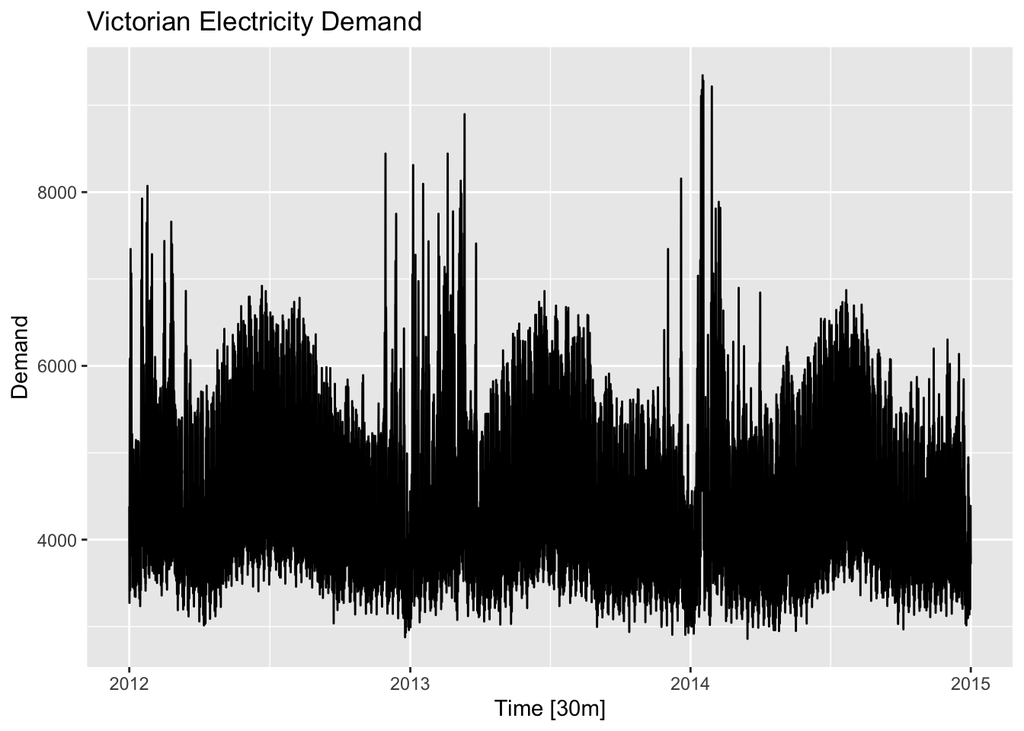

```r
vic_elec |>
  autoplot(Demand) + labs(title = "Victorian Electricity Demand")
```

##Interpretation

we could use a log transformation for vic_elec observation over time, and by using a log transformation we see that the original series ranges differ from the transformed series ranges, but the overall pattern and variability remain similar to the original series.

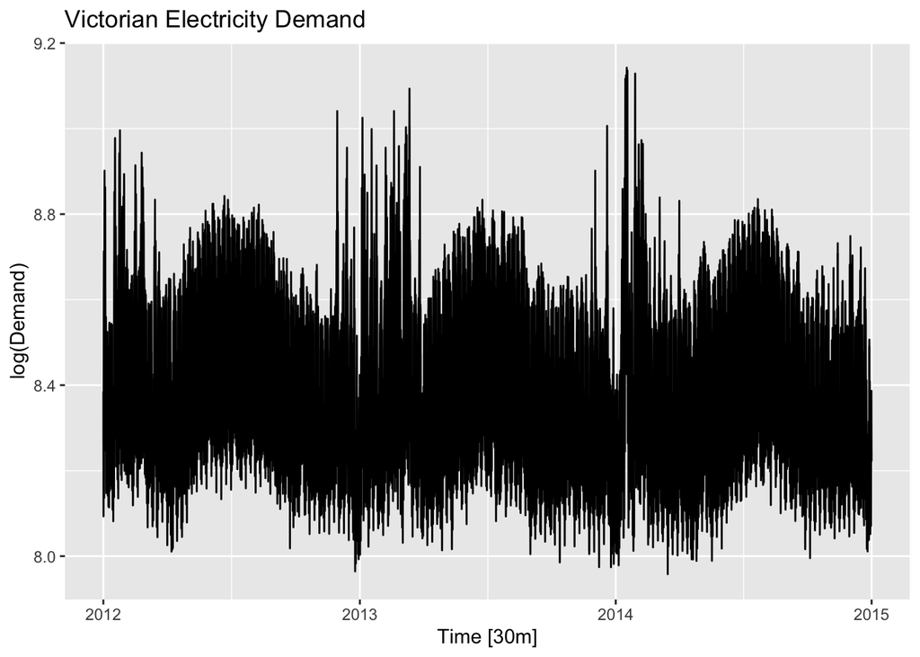

```r
vic_elec |>
  autoplot(log(Demand)) + labs(title = "Victorian Electricity Demand")
```

- Gas production from `aus_production`.

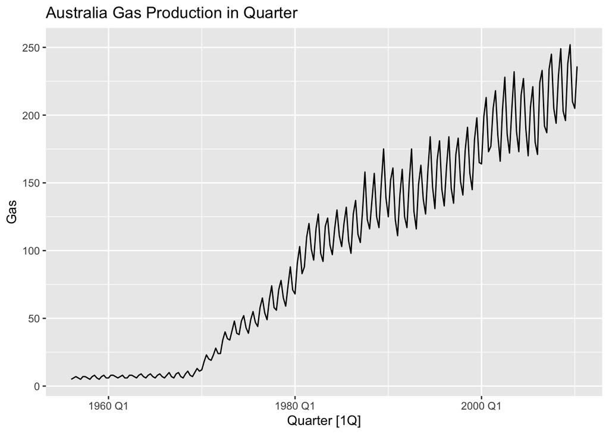

```r
aus_production |>
  autoplot(Gas) + labs(title = "Australia Gas Production in Quarter")
```

**##Interpretation**

The original gas production series shows an upward trend and seasonal fluctuations whose size changes with the level of the series. The log transformation compresses the larger values and makes the variation more stable over time.

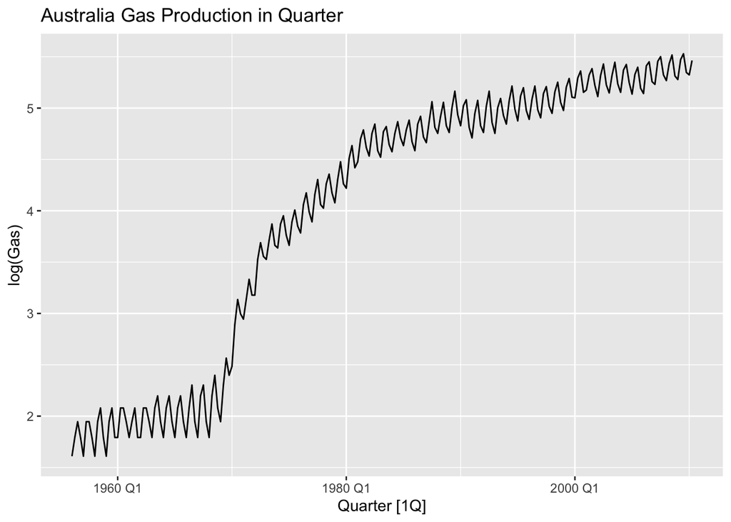

```r
aus_production |>
  autoplot(log(Gas)) + labs(title = "Australia Gas Production in Quarter")
```

let explore the canadian_gas data with a plot

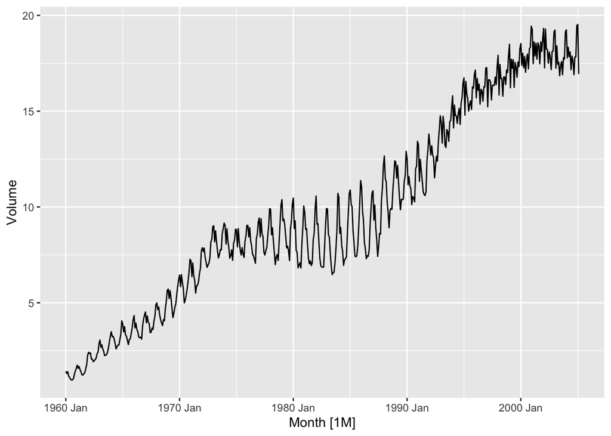

```r
canadian_gas |> autoplot(Volume)
```

explore with Box - Cox

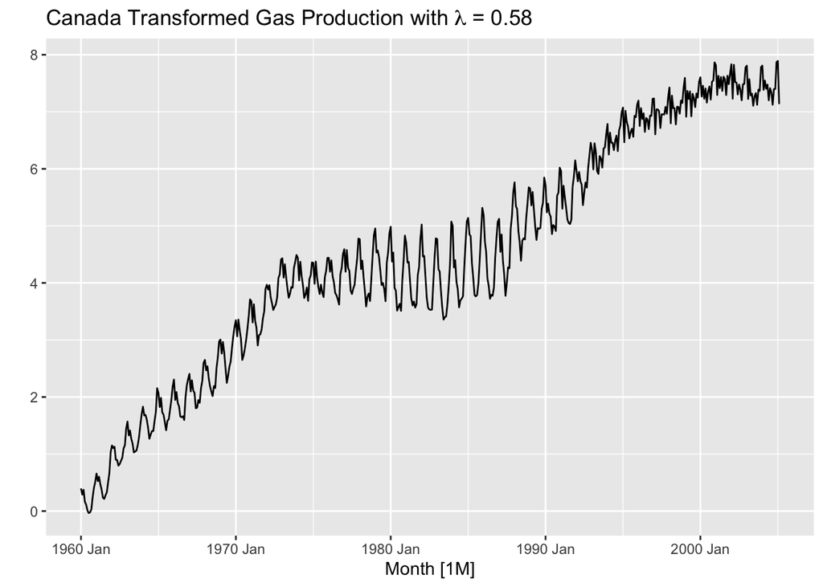

```r
lambda <- canadian_gas |>
  features(Volume, features = guerrero) |>
  pull(lambda_guerrero)

canadian_gas |> autoplot(box_cox(Volume, lambda)) +
  labs(y = "",
       title = latex2exp::TeX(paste0( "Canada Transformed Gas Production with $\\lambda$ = ", round(lambda, 2))))
```

**##Interpretation**

Applying a Box–Cox transformation to the Canadian gas production data is not particularly helpful. Although the Guerrero method gives λ = 0.58 and the transformation changes the scale of the data, the overall pattern and variability remain similar to the original series. Therefore, the Box–Cox transformation does not provide a substantial improvement in stabilizing the variance.

## **3.4. What Box-Cox transformation would you select for your retail data (from Exercise 7 in Section [2.10](https://otexts.com/fpp3/graphics-exercises.html#graphics-exercises))?**

```r
set.seed(12345678)
myseries <- aus_retail |>
  filter(`Series ID` == sample(aus_retail$`Series ID`,1))

lambda <- myseries |>
  features(Turnover, features = guerrero) |>
  pull(lambda_guerrero)
lambda
```

```
[1] 0.08303631
```

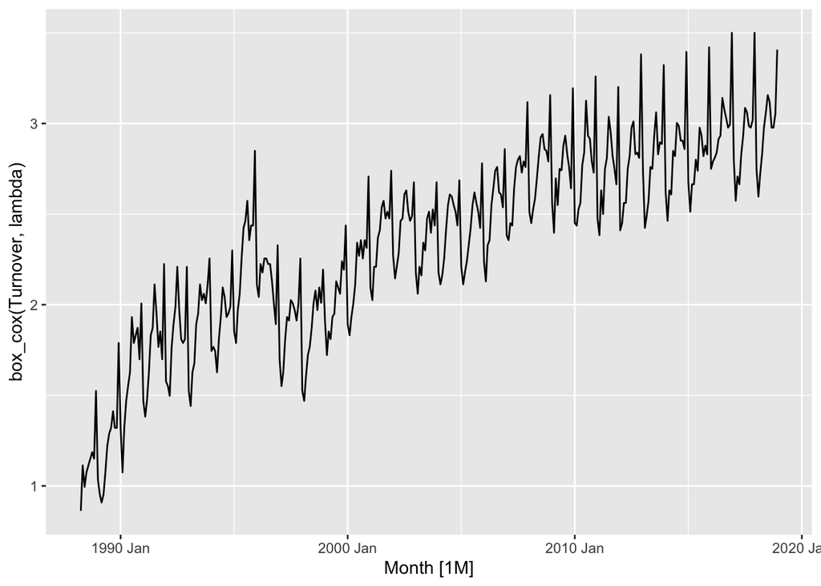

```r
myseries |> autoplot(box_cox(Turnover, lambda))
```

**##Interpretation**

The box-cox I would select for my retail data from Exercise 7 in section 2.10 is automatically calculating the lambda = 0.083 using features guerrero that will generate a lambda value we will use.

## **3.5. For the following series, find an appropriate Box-Cox transformation in order to stabilise the variance. Tobacco from `aus_production`, Economy class passengers between Melbourne and Sydney from `ansett`, and Pedestrian counts at Southern Cross Station from `pedestrian`.**

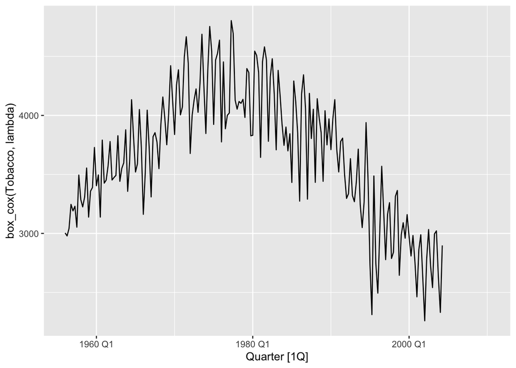

```r
lambda <- aus_production |>
  features(Tobacco, features = guerrero) |>
  pull(lambda_guerrero)

aus_production |> autoplot(box_cox(Tobacco, lambda), na.rm = TRUE)
```

**##Interpretation**

To find an appropriate Box-Cox transformation in order to stabilise the variance. we use the features guerrero which provide a lambda that we apply to plot the graph therefor we can observe the graph shap for Australian tobacco production.

```r
ansett_mel_syd <- ansett |>
  filter(
    Class == "Economy",
    Airports == "MEL-SYD"
  )

lambda <- ansett_mel_syd |>
  features(Passengers, features = guerrero) |>
  pull(lambda_guerrero)

lambda
```

```
[1] 1.999927
```

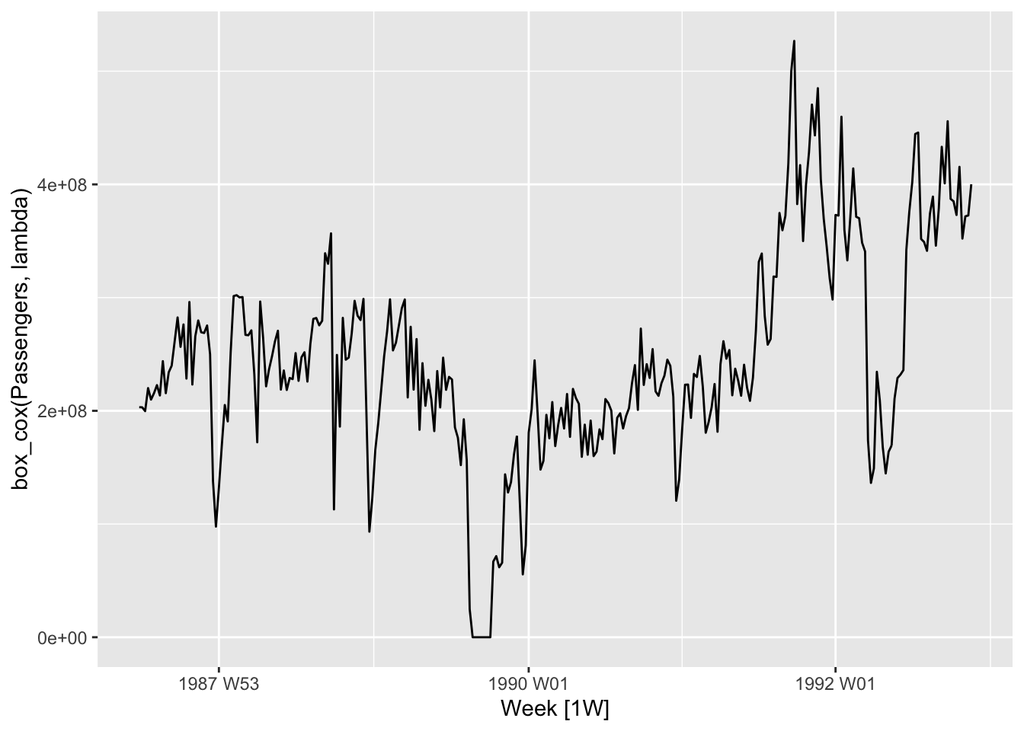

```r
ansett_mel_syd |>
  autoplot(box_cox(Passengers, lambda))
```

**##Interpretation**

To find an appropriate Box-Cox transformation in order to stabilize the variance. we use the features guerrero which provide a lambda that we apply to plot the graph therefor we can observe the graph shape for ansett Economy flights. so we can concluded using box-cox is suitable.

```r
southern_cross <- pedestrian |>
  filter(Sensor == "Southern Cross Station")

lambda <- southern_cross |>
  features(Count, features = guerrero) |>
  pull(lambda_guerrero)

lambda
```

```
[1] -0.2501616
```

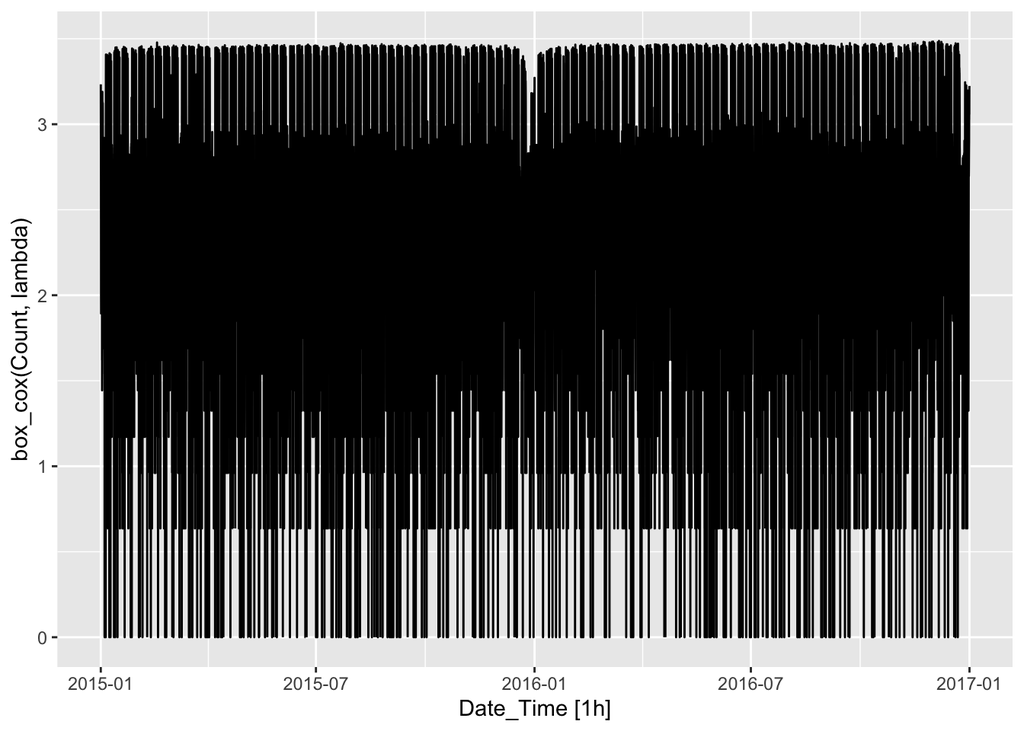

```r
pedestrian |>
  filter(Sensor == "Southern Cross Station") |>
  autoplot(box_cox(Count, lambda))
```

**##Interpretation**

the series contains zero observations, making a standard Box-Cox transformation unsuitable without modifying the data.

## **3.6. Show that a** 3×5 **MA is equivalent to a 7-term weighted moving average with weights of 0.067, 0.133, 0.200, 0.200, 0.200, 0.133, and 0.067.**

6. for 5-MA:

   $M_t = \frac{1}{5}(y_{t-2} + y_{t-1} + y_t + y_{t+1} + y_{t+2})$

   for 3x5 MA is:

   $$T_t = \frac{1}{3}(M_{t-1} + M_t + M_{t+1})$$

   for 5-MAs:

   $M_{t-1} = \frac{1}{5}(y_{t-3} + y_{t-2} + y_{t-1} + y_t + y_{t+1})$

$M_t = \frac{1}{5}(y_{t-2} + y_{t-1} + y_t + y_{t+1} + y_{t+2})$

$M_{t+1} = \frac{1}{5}(y_{t-1} + y_t + y_{t+1} + y_{t+2} + y_{t+3})$

for Averaging 3 groups of 5 we have:

$\frac{1}{3} \times \frac{1}{5} = \frac{1}{15}\approx 0.067$

by counting the number of occur in each equation we get:

$y_{t-3} = 1$ , $y_{t-2} = 2$ , $y_{t-1} = 3$, $y_t = 3$, $y_{t+1} = 3$, $y_{t+2} = 2$, $y_{t+3} = 1$

each result divided by 15 we get:

$T_t = 0.067y_{t-3} +0.133y_{t-2} +0.200y_{t-1} + 0.200y_t + 0.200y_{t+1} + 0.133y_{t+2} + 0.067y_{t+3}$

## 3.7. **Consider the last five years of the Gas data from `aus_production`.**

### **a. Plot the time series. Can you identify seasonal fluctuations and/or a trend-cycle?**

```r
gas <- tail(aus_production, 5*4) |> select(Gas)
gas
```

```
# A tsibble: 20 x 2 [1Q]
     Gas Quarter
   <dbl>   <qtr>
 1   221 2005 Q3
 2   180 2005 Q4
 3   171 2006 Q1
 4   224 2006 Q2
 5   233 2006 Q3
 6   192 2006 Q4
 7   187 2007 Q1
 8   234 2007 Q2
 9   245 2007 Q3
10   205 2007 Q4
11   194 2008 Q1
12   229 2008 Q2
13   249 2008 Q3
14   203 2008 Q4
15   196 2009 Q1
16   238 2009 Q2
17   252 2009 Q3
18   210 2009 Q4
19   205 2010 Q1
20   236 2010 Q2
```

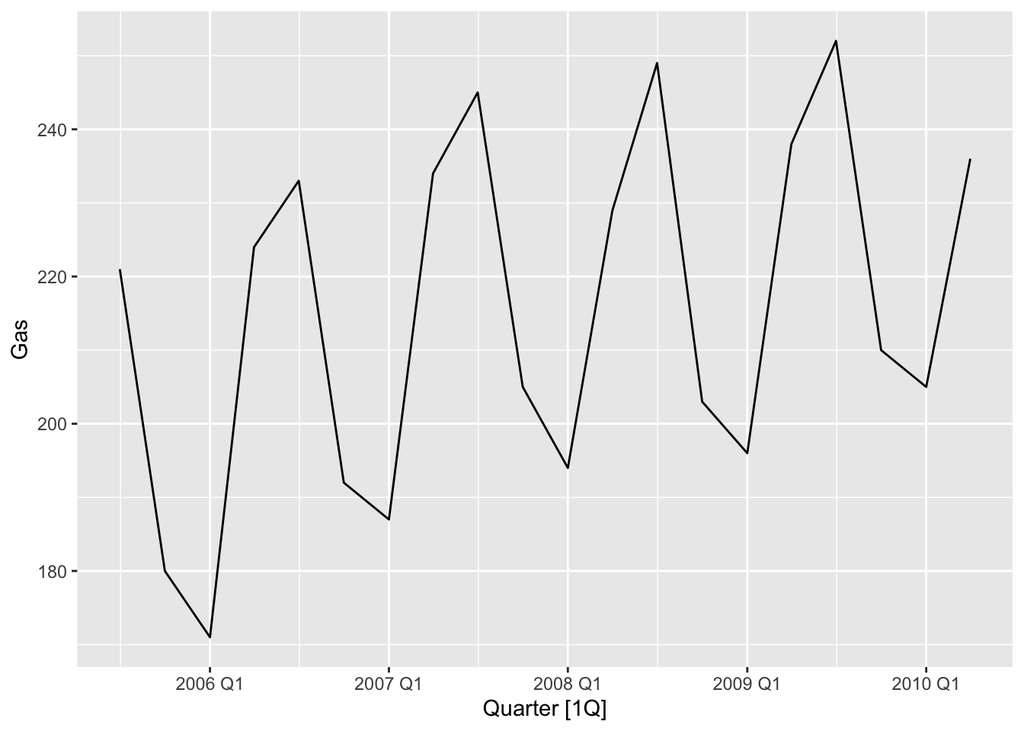

```r
gas |> autoplot(Gas)
```

## **Interpretation**

The series shows a repeating quarterly seasonal pattern over the five-year period. Gas production rises and falls at similar times each year, indicating strong seasonality. There is also an overall upward trend in gas production.

### **b. Use `classical_decomposition` with `type=multiplicative` to calculate the trend-cycle and seasonal indices.**

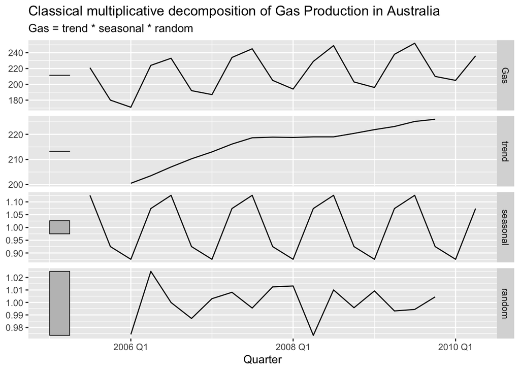

```r
gas |>
  model(classical_decomposition(Gas, type = "multiplicative")) |>
  components() |>
  autoplot(Gas, na.rm = TRUE) +
  labs(title = "Classical multiplicative decomposition of Gas Production in Australia")
```

### **c. Do the results support the graphical interpretation from part a?**

The results support the graphical interpretation from part (a). The classical decomposition shows a clear upward trend and a strong repeating quarterly seasonal pattern.

### **d. Compute and plot the seasonally adjusted data.**

```r
gas_dcmp <- gas |>
  model(
    classical_decomposition(Gas, type = "multiplicative")
  ) |>
  components()
gas_dcmp
```

```
# A dable: 20 x 7 [1Q]
# Key:     .model [1]
# :        Gas = trend * seasonal * random
   .model                      Quarter   Gas trend seasonal random season_adjust
   <chr>                         <qtr> <dbl> <dbl>    <dbl>  <dbl>         <dbl>
 1 "classical_decomposition(G… 2005 Q3   221   NA     1.13  NA              196.
 2 "classical_decomposition(G… 2005 Q4   180   NA     0.925 NA              195.
 3 "classical_decomposition(G… 2006 Q1   171  200.    0.875  0.974          195.
 4 "classical_decomposition(G… 2006 Q2   224  204.    1.07   1.02           209.
 5 "classical_decomposition(G… 2006 Q3   233  207     1.13   1.000          207.
 6 "classical_decomposition(G… 2006 Q4   192  210.    0.925  0.987          208.
 7 "classical_decomposition(G… 2007 Q1   187  213     0.875  1.00           214.
 8 "classical_decomposition(G… 2007 Q2   234  216.    1.07   1.01           218.
 9 "classical_decomposition(G… 2007 Q3   245  219.    1.13   0.996          218.
10 "classical_decomposition(G… 2007 Q4   205  219.    0.925  1.01           222.
11 "classical_decomposition(G… 2008 Q1   194  219.    0.875  1.01           222.
12 "classical_decomposition(G… 2008 Q2   229  219     1.07   0.974          213.
13 "classical_decomposition(G… 2008 Q3   249  219     1.13   1.01           221.
14 "classical_decomposition(G… 2008 Q4   203  220.    0.925  0.996          219.
15 "classical_decomposition(G… 2009 Q1   196  222.    0.875  1.01           224.
16 "classical_decomposition(G… 2009 Q2   238  223.    1.07   0.993          222.
17 "classical_decomposition(G… 2009 Q3   252  225.    1.13   0.994          224.
18 "classical_decomposition(G… 2009 Q4   210  226     0.925  1.00           227.
19 "classical_decomposition(G… 2010 Q1   205   NA     0.875 NA              234.
20 "classical_decomposition(G… 2010 Q2   236   NA     1.07  NA              220.
```

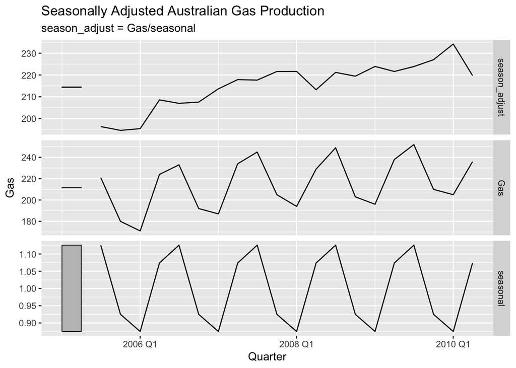

```r
gas_dcmp |>
  autoplot(season_adjust) +
  labs(
    title = "Seasonally Adjusted Australian Gas Production",
    x = "Quarter",
    y = "Gas"
  )
```

### **e. Change one observation to be an outlier (e.g., add 300 to one observation), and recompute the seasonally adjusted data. What is the effect of the outlier?**

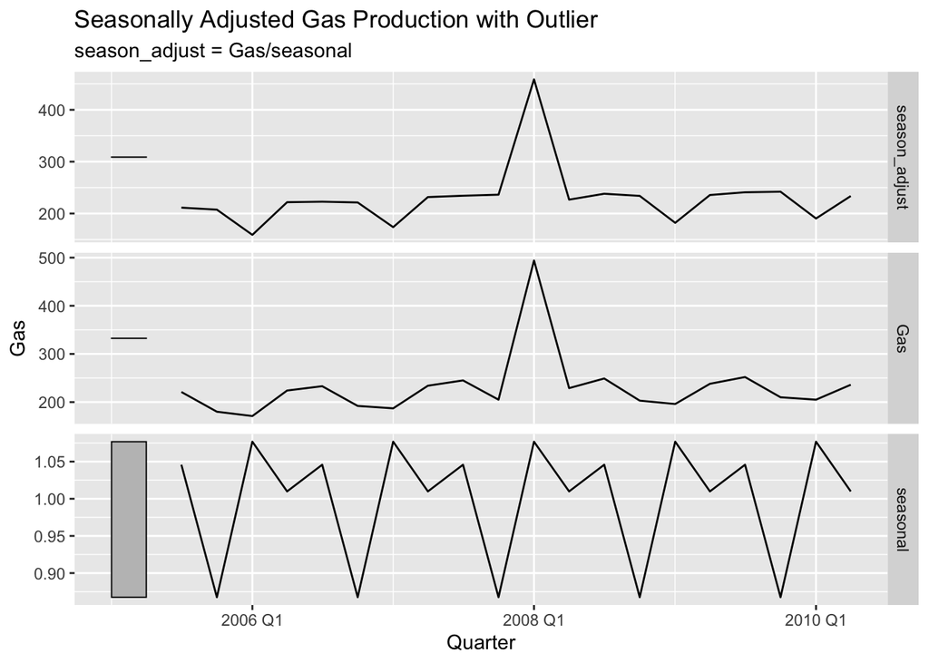

```r
gas_outlier <- gas |>
  mutate(
    Gas = if_else(
      Quarter == yearquarter("2008 Q1"),
      Gas + 300,
      Gas
    )
  )
gas_outlier_dcmp <- gas_outlier |>
  model(
    classical_decomposition(Gas, type = "multiplicative")
  ) |>
  components()
gas_outlier_dcmp |>
  autoplot(season_adjust) +
  labs(
    title = "Seasonally Adjusted Gas Production with Outlier",
    x = "Quarter",
    y = "Gas"
  )
```

## **Interpretation**

Adding 300 to one observation creates a large spike in the seasonally adjusted data. The outlier has a strong effect on that observation and can also affect the estimated components used in the classical decomposition.

### **f. Does it make any difference if the outlier is near the end rather than in the middle of the time series?**

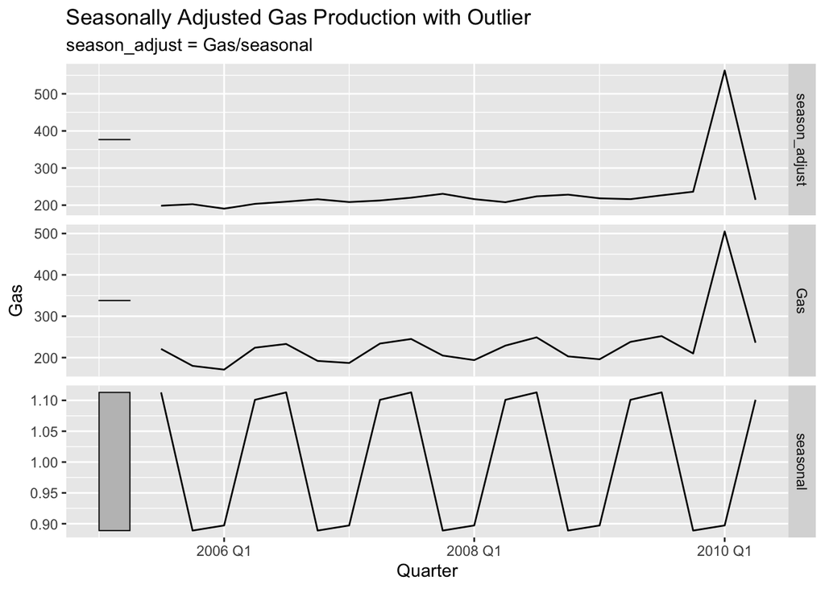

```r
gas_outlier <- gas |>
  mutate(
    Gas = if_else(
      Quarter == yearquarter("2010 Q1"),
      Gas + 300,
      Gas
    )
  )
gas_outlier_dcmp <- gas_outlier |>
  model(
    classical_decomposition(Gas, type = "multiplicative")
  ) |>
  components()
gas_outlier_dcmp |>
  autoplot(season_adjust) +
  labs(
    title = "Seasonally Adjusted Gas Production with Outlier",
    x = "Quarter",
    y = "Gas"
  )
```

## **Interpretation**

Yes, it makes a difference when the outlier is near the end rather than in the middle of the time series. An outlier in the middle can affect the estimated trend-cycle around it because there are observations on both sides. Near the end, the trend-cycle cannot be estimated in the same way because there are not enough observations after the outlier. Therefore, the position of the outlier affects the classical decomposition and the seasonally adjusted data.

## **3.8. Recall your retail time series data (from Exercise 7 in Section [2.10](https://otexts.com/fpp3/graphics-exercises.html#graphics-exercises)). Decompose the series using X-11. Does it reveal any outliers, or unusual features that you had not noticed previously?**

```r
#install.packages("seasonal")
library(seasonal)
set.seed(12345678)
myseries <- aus_retail |>
  filter(`Series ID` == sample(aus_retail$`Series ID`,1))
myseries
```

```
# A tsibble: 369 x 5 [1M]
# Key:       State, Industry [1]
   State              Industry                     `Series ID`    Month Turnover
   <chr>              <chr>                        <chr>          <mth>    <dbl>
 1 Northern Territory Clothing, footwear and pers… A3349767W   1988 Apr      2.3
 2 Northern Territory Clothing, footwear and pers… A3349767W   1988 May      2.9
 3 Northern Territory Clothing, footwear and pers… A3349767W   1988 Jun      2.6
 4 Northern Territory Clothing, footwear and pers… A3349767W   1988 Jul      2.8
 5 Northern Territory Clothing, footwear and pers… A3349767W   1988 Aug      2.9
 6 Northern Territory Clothing, footwear and pers… A3349767W   1988 Sep      3
 7 Northern Territory Clothing, footwear and pers… A3349767W   1988 Oct      3.1
 8 Northern Territory Clothing, footwear and pers… A3349767W   1988 Nov      3
 9 Northern Territory Clothing, footwear and pers… A3349767W   1988 Dec      4.2
10 Northern Territory Clothing, footwear and pers… A3349767W   1989 Jan      2.7
# ℹ 359 more rows
```

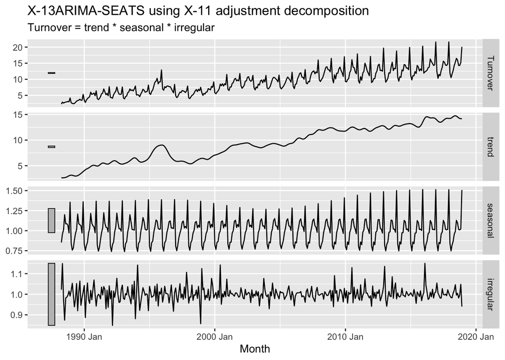

```r
retail_outlier_dcmp <- myseries |>
  model(
    x11 = X_13ARIMA_SEATS(Turnover ~ x11())
  )

retail_outlier_dcmp |>
  components() |>
  autoplot()
```

## **Interpretation**

Observing the remainder component, we can see some unusual positive and negative spikes that were not as noticeable in the original time series. These large deviations represent observations that are not explained by the trend or seasonal components and may indicate unusual events or outliers.

## **3.9. Figures [3.19](https://otexts.com/fpp3/decomposition-exercises.html#fig:labour) and [3.20](https://otexts.com/fpp3/decomposition-exercises.html#fig:labour2) show the result of decomposing the number of persons in the civilian labor force in Australia each month from February 1978 to August 1995.**

### **a. Write about 3–5 sentences describing the results of the decomposition. Pay particular attention to the scales of the graphs in making your interpretation.**

The decomposition shows a smooth upward trend in the Australian civilian labor force from 1978 to 1995. The seasonal component ranges approximately from −100 to +100 and shows a consistent seasonal pattern. December and March have relatively large positive seasonal effects, while January and August have large negative seasonal effects. Compared with the overall level of the series, which increases from approximately 6,500 to 9,000, the seasonal fluctuations are relatively small.

### **b. Is the recession of 1991/1992 visible in the estimated components?**

Yes, the recession of 1991/1992 is visible in the decomposition. The trend component shows that the growth of the labor force slows considerably around 1991–1992. The remainder also shows unusually large negative values around 1991, including a decline of approximately −400.